# Decision Trees and Random Forests

```python
import pandas as pd
import numpy as np
import matplotlib.pyplot as plt
from intro_Data_4_3 import *
import seaborn as sns
```

```python
from sklearn.datasets import load_iris as li
```

## 1. DTC with a two-features example (iris data)

```python
# Load data and split into features and targets

iris = li()
X = iris.data
X_names = iris.feature_names
y = iris.target
y_names = iris.target_names

X_df = pd.DataFrame(X,columns=X_names)
X_df.head()
```

|  | sepal length (cm) | sepal width (cm) | petal length (cm) | petal width (cm) |
| --- | --- | --- | --- | --- |
| 0 | 5.1 | 3.5 | 1.4 | 0.2 |
| 1 | 4.9 | 3.0 | 1.4 | 0.2 |
| 2 | 4.7 | 3.2 | 1.3 | 0.2 |
| 3 | 4.6 | 3.1 | 1.5 | 0.2 |
| 4 | 5.0 | 3.6 | 1.4 | 0.2 |

```python
# Taking two features from X
cols = ['petal width (cm)', 'sepal length (cm)']
X1 = np.array(X_df[cols])
```

Let's start with a single training/testing split and inspect the results, while varying some of the hyperparamters of the decision tree:

```python
from sklearn.model_selection import train_test_split as tts
Xtrain,Xtest,ytrain,ytest = tts(X1, y, test_size=0.4, random_state=146)
```

There are a few hyperparameters for DTC --- they help control the size and complexity of the tree

**min_samples_split** (the minimum number of samples a node must have before it can be split)  
**min_samples_leaf** (the minimum number of samples a leaf node must have)  
**min_weight_fraction_leaf** (same as min_samples_leaf but expressed as a fraction of the total number of weighted instances --- To illustrate, suppose we have a dataset with 100 samples and min_weight_fraction_leaf is set to 0.1. In this case, each leaf node must contain at least 10% of the total sum of weights of the input samples, which translates to at least 10 samples in this example.)  
**max_leaf_nodes** (the maximum number of leaf nodes), and  
**max_features** (the maximum number of features that are evaluated for splitting at each node; for example, max_features=5 means that the algorithm will only consider 5 features (chosen randomly) at each split.).

```python
# Try playing around with the hyperparas to see how this changes the results

from sklearn.tree import DecisionTreeClassifier as DTC

dtc = DTC(random_state=146, min_samples_split = 5)
dtc.fit(Xtrain,ytrain)
y_pred = dtc.predict(Xtest)

# Train scores (overfitting?)
print("Train accuracy: ", dtc.score(Xtrain,ytrain))

conf_matrix, accuracy = compare_classes(ytest,y_pred,y_names)
conf_matrix
```

```
Train accuracy:  0.9666666666666667
Test accuracy = 0.95
```

| Predicted Actual | setosa | versicolor | virginica |
| --- | --- | --- | --- |
| setosa | 15 | 0 | 0 |
| versicolor | 0 | 23 | 3 |
| virginica | 0 | 0 | 19 |

We can also look at the tree itself. Let's check it out for different hyperparameter values.

**samples** counts how many training instances it applies to.  
**value** tells you how many training instances of each class this node applies to.  
**gini** measures its impurity. The Gini impurity of a node is the probability that a data point within the node would be mislabeled, if it were assigned a label at random with probabilities proportional to the frequency of the labels within the node.

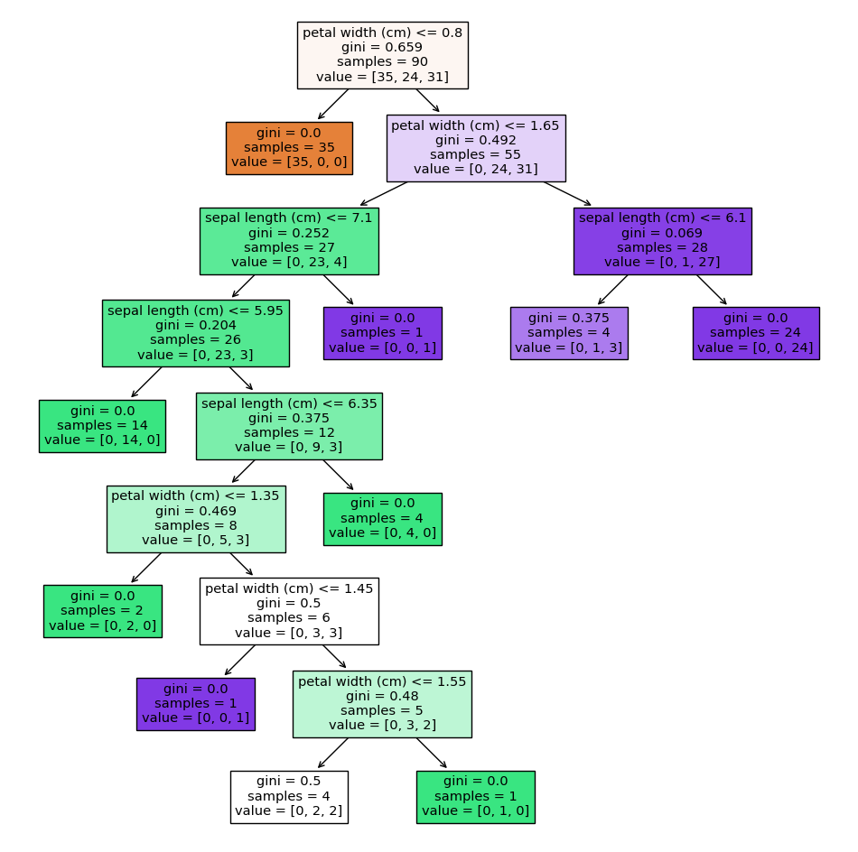

```python
# Visualize the decision tree

from sklearn import tree
plt.figure(figsize=(12,12))
tree.plot_tree(dtc,filled=True, feature_names = cols)
plt.savefig('IrisDecisionTree_Example.svg', bbox_inches='tight')
plt.show()
```

Let's look at the classification regions (and perhaps see how they change when we change the max depth)

[figure not shown]

```python
# Plot the classification regions along with the test data

x_range = np.linspace(X1[:,0].min(), X1[:,0].max(), 60)
y_range = np.linspace(X1[:,1].min(), X1[:,1].max(), 60)


# A function that generates grids
points = make_grid(x_range,y_range)



y_regions = dtc.predict(points)



# Need some colors for our plot
front_colors = ['red', 'blue', 'yellow']
back_colors = ['magenta', 'cyan', 'orange']

# plot grids
fig,ax = plot_groups(points,y_regions, back_colors,ec='None',s=50, alpha = 0.1)
# plot train data
#plot_groups(Xtrain,ytrain,front_colors,ax=ax, s = 60, alpha = 0.5)
# plot test data
plot_groups(Xtest,ytest,front_colors,ax=ax, s = 60, alpha = 1)

plt.xlabel(cols[0])
plt.ylabel(cols[1])
plt.legend(y_names, bbox_to_anchor=[1,0.5], loc='center left')
plt.show()
```

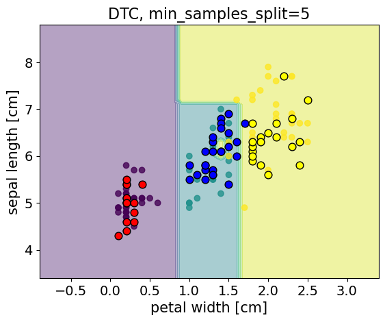

```python
plt.figure()
plt.title("DTC, min_samples_split=5",fontsize=16)
plot_decision_boundaries(Xtrain,ytrain,DTC,min_samples_split = 5)
plt.xlabel("petal width [cm]",fontsize=15)
plt.ylabel("sepal length [cm]",fontsize=15)
for yi in np.unique(ytest):
        idx = ytest == yi
        plt.scatter(Xtest[idx,0], Xtest[idx,1],color = front_colors[yi], alpha = 1, s = 60, ec = 'k')
plt.show()
```

## 2. DTC with all features and hyperparameter selection

```python
# Get train/test scores/accuracy for a range of max_depth values

depth_range = np.arange(2,10)
k = 10

train = []
test = []

for d in depth_range:
    dtc = DTC(max_depth = d, random_state=146)
    tr,te  = do_Kfold(dtc,X,y,k)
    train.append(np.mean(tr))
    test.append(np.mean(te))
```

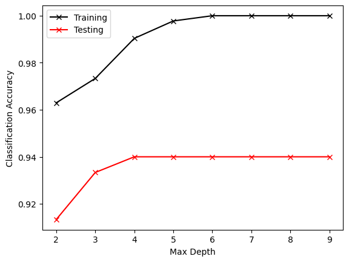

```python
# plot accuracy-max_depth curve

plt.plot(depth_range, train, '-xk', label='Training')
plt.plot(depth_range, test, '-xr', label='Testing')
plt.xlabel('Max Depth')
plt.ylabel('Classification Accuracy')
plt.legend()
plt.show()
```

In practice, you could probably improve performance overall by modifying multiple hyperparameters (we will talk about an easier way to do that later).

```python
# get optimal max_depth value
idx = test == np.max(test)
print('Optimal #neighbors: ', depth_range[idx])
print('Optimal test score: ', np.max(test))
```

```
Optimal #neighbors:  [4 5 6 7 8 9]
Optimal test score:  0.9400000000000001
```

```python
# get mean train/test scores with optimal max_depth using K fold cross-validation
tr,te = do_Kfold(DTC(random_state = 146, max_depth = 4),X,y,10)
print(np.mean(tr), np.mean(te))
```

```
0.9903703703703703 0.9400000000000001
```

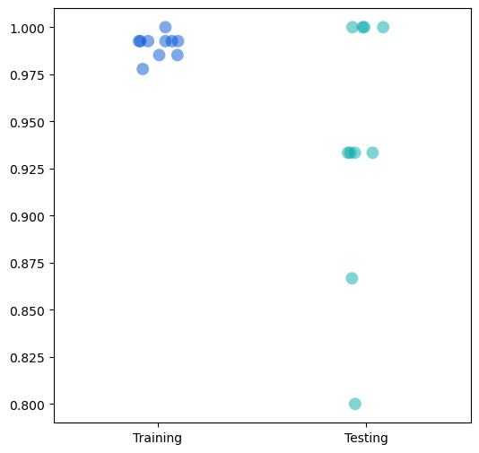

```python
# visualize train/test scores with stripplot
plt.figure(figsize = (6,6))
sns.stripplot(data = pd.DataFrame(zip(tr,te), columns = ['Training', 'Testing']), size=10, palette = 'winter',
             alpha = 0.5, jitter = True)
plt.show()
```

## 3. Random Forests

Let's take a look with just two predictors so that we can compare the results from using a Random Forest versus a single decision tree.

```python
# Train a Random Forest classifier

from sklearn.ensemble import RandomForestClassifier as RFC

cols = ['petal width (cm)', 'sepal length (cm)']
X1 = X_df[cols]

Xtrain,Xtest,ytrain,ytest = tts(X1.values,y,test_size=0.4, random_state = 146)

rfc = RFC(random_state=146, n_estimators=100, max_depth = 4)
rfc.fit(Xtrain,ytrain)
y_pred = rfc.predict(Xtest)
```

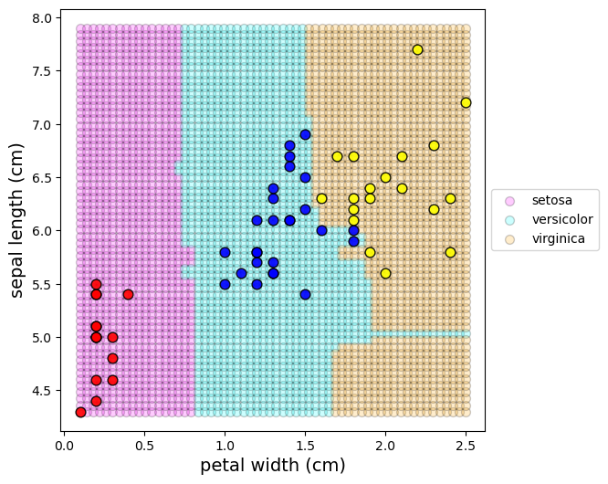

```python
# Plot the classification regions along with the test data

x_range = np.linspace(X1.values[:,0].min(), X1.values[:,0].max(), 60)
y_range = np.linspace(X1.values[:,1].min(), X1.values[:,1].max(), 60)

points = make_grid(x_range,y_range)

y_regions = rfc.predict(points)

# Need some colors for our plot
front_colors = ['red', 'blue', 'yellow']
back_colors = ['magenta', 'cyan', 'orange']

fig,ax = plot_groups(points,y_regions, back_colors, ec='None',s=50, alpha = 0.2)
#plot_groups(Xtest,ytest,front_colors,ax=ax, s = 60, alpha = 0.9)
plot_groups(Xtest,y_pred,front_colors,ax=ax, s = 60, alpha = 0.9)

plt.xlabel(cols[0])
plt.ylabel(cols[1])
plt.legend(y_names, bbox_to_anchor=[1,0.5], loc='center left')
plt.show()
```

What's different about the classification regions?

```python
# Get the confusion matrix
conf_matrix, accuracy = compare_classes(ytest, y_pred, y_names)
conf_matrix
```

```
Test accuracy = 0.93
```

| Predicted Actual | setosa | versicolor | virginica |
| --- | --- | --- | --- |
| setosa | 15 | 0 | 0 |
| versicolor | 0 | 24 | 2 |
| virginica | 0 | 2 | 17 |

```python
# An alternative way using the confusion_matrix function from sklearn
from sklearn.metrics import confusion_matrix as CM
conf_matrix2 = CM(ytest, y_pred)
conf_matrix2
```

```
array([[15,  0,  0],
       [ 0, 24,  2],
       [ 0,  2, 17]])
```

The optimal hyperparameters for a decision tree may not be optimal for the Random Forest. Let's use all of the data and try to optimize max_depth for 100 trees.

```python
# Find optimal max_depth for RFC

depth_range = np.arange(2,10)
k = 10

train = []
test = []

for d in depth_range:
    rfc = RFC(n_estimators = 100, max_depth = d, random_state=146)
    tr,te  = do_Kfold(rfc,X,y,k)
    train.append(np.mean(tr))
    test.append(np.mean(te))
```

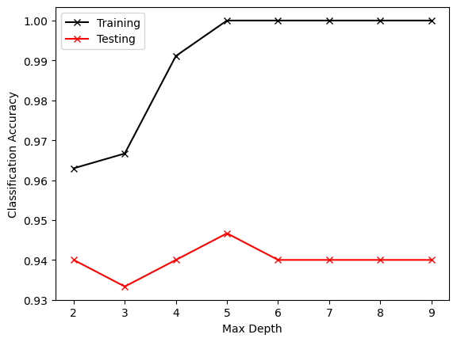

```python
# Plot the accuracy-max_depth curve

plt.plot(depth_range, train, '-xk', label='Training')
plt.plot(depth_range, test, '-xr', label='Testing')
plt.xlabel('Max Depth')
plt.ylabel('Classification Accuracy')
plt.legend()
plt.show()
```

Let's **compare DTC with RFC** on 1 tts with all predictors:

```python
Xtrain,Xtest,ytrain,ytest = tts(X,y,test_size=0.4, random_state = 146)
```

```python
dtc = DTC(random_state = 146, max_depth = 4)
dtc.fit(Xtrain, ytrain)
print("Train accuracy is: ", dtc.score(Xtrain,ytrain))
conf_matrix, accuracy = compare_classes(ytest, dtc.predict(Xtest), y_names)
conf_matrix
```

```
Train accuracy is:  1.0
Test accuracy = 0.93
```

| Predicted Actual | setosa | versicolor | virginica |
| --- | --- | --- | --- |
| setosa | 15 | 0 | 0 |
| versicolor | 0 | 24 | 2 |
| virginica | 0 | 2 | 17 |

```python
rfc = RFC(random_state = 146, n_estimators = 100, max_depth = 5)
rfc.fit(Xtrain, ytrain)
print("Train accuracy is: ", rfc.score(Xtrain,ytrain))
conf_matrix, accuracy = compare_classes(ytest, dtc.predict(Xtest), y_names)
conf_matrix
```

```
Train accuracy is:  1.0
Test accuracy = 0.93
```

| Predicted Actual | setosa | versicolor | virginica |
| --- | --- | --- | --- |
| setosa | 15 | 0 | 0 |
| versicolor | 0 | 24 | 2 |
| virginica | 0 | 2 | 17 |

## 4. Grid search

Given a set of hyperparameters, how would you decide which is the best combination of hyperparameters?  
**Grid search** is a basic method to do it. The key idea is to define a grid of hyperparameter values, use cross-validation to evaluate each of the combination, and then get the best combination from the validation scores (accuracy in the context of classification).

### Grid search for RFC

```python
# Grid search for RFC

from sklearn.model_selection import KFold, GridSearchCV

# create a grid of parameter values
param_grid_rfc = dict(n_estimators=[1,100,500],max_depth = [2,3,4,5],
                 min_samples_split = [2,3,4,5])
# specify how you want to do the cross-validation
cv = KFold(n_splits=10, random_state=146, shuffle = True)
grid_rfc = GridSearchCV(RFC(random_state = 146), param_grid=param_grid_rfc, cv=cv,
                    scoring='accuracy')

# perform grid search (what is this really doing?)
grid_rfc.fit(X, y)
```

```python
print(
    f'The best parameters are {grid_rfc.best_params_} with a score of {grid_rfc.best_score_:.2f}'
)
```

[output not shown]

```python
results = pd.DataFrame(grid_rfc.cv_results_)[['param_n_estimators','param_max_depth',
                                'param_min_samples_split','mean_test_score','rank_test_score']]
```

```python
results.head()
```

[output not shown]

```python
results[results['rank_test_score'] == 1]
```

[output not shown]

### What about DTC?

```python
# Grid search for DTC
param_grid_dtc = dict(max_depth = [2,3,4,5],
                 min_samples_split = [2,3,4,5]) #params to test
cv = KFold(n_splits=10, random_state=146, shuffle = True)
grid_dtc = GridSearchCV(DTC(random_state = 146), param_grid=param_grid_dtc, cv=cv,
                    scoring='accuracy')
grid_dtc.fit(X, y)
```

```python
print(
    f'The best parameters are {grid_dtc.best_params_} with a score of {grid_dtc.best_score_:.2f}'
)
```

[output not shown]

```python
results = pd.DataFrame(grid_dtc.cv_results_)[['param_max_depth',
                                'param_min_samples_split','mean_test_score','rank_test_score']]
```

```python
results.head()
```

[output not shown]

```python
results[results['rank_test_score'] == 1]
```

[output not shown]